# Project Report

Palash Siddamsettiwar, M10676557

December 10, 2016

# Packages Used

- RCurl: To read data off URLs
- DT: To format data into good-looking tables on Markdown
- tidyverse: To clean data and create tibbles
- rworldmap: To create maps and import shapefiles in R
- ggplot2: To create charts and maps in R
- Hmisc: To perform statistical analysis (correlational analysis, in our case) in R

```r
library("RCurl")
library("DT")
library("tidyverse")
library("rworldmap")
library("ggplot2")
library("Hmisc")
```

# 1 Synopsis

## 1.1 Problem Statement

Through this data we attempt to explain CO2 and Methane emissions growth over the years by understanding energy use and demographics.

We look at individual countries and their indicators such as 1. Literacy 2. Poverty 3. GINI Index (Index that looks at divide between poor and rich) 4. Population 5. Unemployment Rate 6. Life Expectancy 7. Sustainable energy use

and try to find which factors affect CO2 and Methane emissions

## 1.2 Data Description and Source

The main data file used contains details about carbon emissions and economic indicators of various countries.

The main data is sourced from [here](http://databank.worldbank.org/data/reports.aspx?Code=NY.GDP.MKTP.CD&id=af3ce82b&report_name=Popular_indicators), Worldbank’s data repository for global indicators.

The second data file contains data about sustainable energy sources and their share in total energy consumption.

Data for the sustainable energy use is sourced from [here](http://data.worldbank.org/data-catalog/sustainable-energy-for-all), Worldbank’s dataset on the ‘Sustainable Energy for All’ initiative.

Here I have downloaded the datasets as an excel along with it’s codebook and uploaded it to my Google Drive.

## 1.3 Methodology Used

In this project, we looked at the carbon emissions against many indicators of a nation, through the use of tecniques such as correlation, visualization techniques and times series analysis. Using these analyses, we try to understand how we can change the trends and pinpoint the most problematic countries and steps they can take to reduce their carbon footprint. We also look at their renewable energy use to understand how they have attempted to reduce carbon emissions.

## 1.4 Summary

From the analysis, relationships between development, demographics and energy use is linked to CO2 emissions. Main countries are found who are causing the highest amount of emissions, and their energy use over the years, renewable energy consumption, etc are compared. Various demographics and economic parameters are compared against CO2 emissions to understand if there is a relation between these. Conclusions are reported in the summary section.

# 2 Data Preparation

## 2.1 Importing data

The data is imported as follows:

```r
data_emissions <- getURL("https://docs.google.com/spreadsheets/d/1NLjID44TrPn6h1YaYLQNcImUD16Z_eVSrIv50_wVOrc/pub?gid=8560543&single=true&output=csv") #Data downloaded from Google Drive
data_emissions <- as_tibble(read.csv(textConnection(data_emissions))) #Data stored as a tibble

data_renewables <- getURL("https://docs.google.com/spreadsheets/d/11hCb1YGsnRZp7w3uCMToUYqpfxgt6jNcnhjXp6CcIvI/pub?gid=1118430051&single=true&output=csv") #Data downloaded from Google Drive
data_renewables <- as_tibble(read.csv(textConnection(data_renewables))) #Data stored as a tibble


data_country <- getURL("https://docs.google.com/spreadsheets/d/11hCb1YGsnRZp7w3uCMToUYqpfxgt6jNcnhjXp6CcIvI/pub?gid=268266810&single=true&output=csv") #Data downloaded from Google Drive
data_country <- as_tibble(read.csv(textConnection(data_country))) #Data stored as a tibble
```

## 2.2 Codebooks

The following tables list the data codebooks to better understand the data:

**1. Emissions Data**: Data is present in a ‘long’ form with all the variables present in a single column and years present in the columns. Missing values are present often in the data and coded as ‘..’.

|  | Code | Indicator.Name | Long.definition | Data.Type |
| --- | --- | --- | --- | --- |
| 1 | SP.DYN.LE00.IN | Life expectancy at birth, total (years) | Indicates the number of years a newborn infant would live. | Decimal |
| 2 | SE.ADT.LITR.ZS | Literacy rate, adult total (% of people aged 15+) | Percentage of literate people ages 15 and above. | Percentage |
| 3 | SL.UEM.TOTL.ZS | Unemployment, total (% of total labor force) | Share of the labor force that is without work but available for employment. | Percentage |
| 4 | SI.POV.NAHC | Poverty headcount (% of population) | Percentage of the population living below the national poverty lines. | Percentage |
| 5 | EN.ATM.CO2E.PC | CO2 emissions (metric tons per capita) | CO2 emissions stemming from burning of fossil fuels and manufacture of cement. | Decimal |
| 6 | SP.POP.TOTL | Population, total | Total population (midyear estimates). | Integer |
| 7 | SI.POV.GINI | GINI index | Gini index: 0- perfect equality, 100- perfect inequality in distribution of income. | Integer |
| 8 | EN.ATM.METH.KT.CE | Methane emissions (kt of CO2 equivalent) | Methane emissions stemming from activities like agriculture and industrial production. | Decimal |
| 9 | EG.ELC.ACCS.ZS | Access to electricity (% of population) | Access to electricity is the percentage of population with access to electricity. | Percentage |
| 10 | EG.USE.PCAP.KG.OE | Energy use (kg of oil equivalent per capita) | Energy use refers to use of primary energy before transformation to other end-use fuels. | Decimal |

[output cut: 3 more lines]

**2. Renewables Data**: Data is present in a ‘long’ form with all the variables present in a single column and years present in the columns. Missing values are present often in the data and are coded as NULL.

|  | Code | Long.definition | Data.Type |
| --- | --- | --- | --- |
| 1 | Country_Name | Name of the country | Character |
| 2 | Country_Code | 3-letter representation for the country | Character |
| 3 | Indicator_Name | Long description of the indicator | Character |
| 4 | Indicator_Code | Coded name for the indicator | Character |
| 5 | 5.1_RE.SHARE.IN.CAPACITY | Share of renewable capacity in total capacity (%) | Percentage |
| 6 | 1.1_TOTAL.FINAL.ENERGY.CONSUM | Total final energy consumtion (TFEC) | Decimal |
| 7 | 2.1.1_SHARE.TRADBIO | Traditional biomass consumption (% in TFEC) | Percentage |
| 8 | 2.1.10_SHARE.MARINE | Marine energy consumption (% in TFEC) | Percentage |
| 9 | 2.1.2_SHARE.MODERNBIO | Modern biomass consumption (% in TFEC) | Percentage |
| 10 | 2.1.3_SHARE.HYDRO | Hydro energy consumption (% in TFEC) | Percentage |

[output cut: 7 more lines]

**3. Countries’ Data**: This data is present for all countries, which regions they fall into and their economic classification.

|  | Code | Long.definition | Data.Type |
| --- | --- | --- | --- |
| 1 | CountryCode | 3-letter representation for the country | Character |
| 2 | Long Name | Full name of the country | Character |
| 3 | Table Name | Name as in the data | Character |
| 4 | Income Group | Income category of the country | Character |
| 5 | Lending category | Lending category of the country | Character |
| 6 | Region | Region/continent that the country belongs in | Character |

## 2.3 Data Cleaning

The data in the three tables is cleaned and merged as follows:

```r
data_emissions[data_emissions=='..'] <- NA
data_emissions <- data_emissions %>%
  gather(key='Year', value='value', `X1992..YR1992.`:`X2014..YR2014.`) %>%
  spread(key='Series.Code', value='value') %>%
  select(-(`Country.Name`)) %>%
  mutate(Year = substr(Year, 2, 5))
data_renewables <- data_renewables %>%
  gather(key='Year', value='value', `X1990`:`X2010`) %>%
  select(-(`Indicator_Name`)) %>%
  spread(key='Indicator_Code', value='value') %>%
  select(c(`Country_Code`, `Year`, `5.1_RE.SHARE.IN.CAPACITY`, `1.1_TOTAL.FINAL.ENERGY.CONSUM`, `2.1_SHARE.TOTAL.RE.IN.TFEC`)) %>%
  mutate(Year = substr(Year, 2, 5))

data_country <- data_country[c(1, 3, 4, 6)]

final <-
data_emissions %>%
  rename(Country_Code = Country.Code) %>%
  left_join(data_renewables, by =c("Country_Code", "Year")) %>%
  right_join(data_country, by= c("Country_Code"="CountryCode")) %>%
  filter(Year %in% c(1996:2010)) %>%
  group_by(Country_Code) %>%
  filter(Region != "Aggregates")
top_countries <- head(final[final$Year==2010,][order(-as.numeric(final[final$Year==2010,]$`SP.POP.TOTL`)),], 30)$Country_Code
final <- final[final$Country_Code %in% top_countries, ]
final[c(3:15)] <- sapply(final[c(3:15)],as.numeric)
final$EN.ATM.CO2E <- final$EN.ATM.CO2E.PC*final$SP.POP.TOTL
final$EG.USE.KG.OE <- final$EG.USE.PCAP.KG.OE*final$SP.POP.TOTL
```

## 2.4 Cleaned Dataset

```r
datatable(final,
          style="bootstrap",
          options = list(scrollX = TRUE))
```

|  | Country_Code | Year | EG.ELC.ACCS.ZS | EG.USE.PCAP.KG.OE | EN.ATM.CO2E.PC | EN.ATM.METH.KT.CE | SE.ADT.LITR.ZS | SI.POV.GINI | SI.POV.NAHC | SL.UEM.TOTL.ZS | SP.DYN.LE00.IN | SP.POP.TOTL | 5.1_RE.SHARE.IN.CAPACITY | 1.1_TOTAL.FINAL.ENERGY.CONSUM | 2.1_SHARE.TOTAL.RE.IN.TFEC | Table.Name | Income.Group | Region | EN.ATM.CO2E | EG.USE.KG.OE |
| --- | --- | --- | --- | --- | --- | --- | --- | --- | --- | --- | --- | --- | --- | --- | --- | --- | --- | --- | --- | --- |
| 1 | BGD | 1996 |  | 132.1986545 | 0.1986149452 | 86646.3 |  |  |  | 2.5 | 62.62956098 | 120987124 | 6.96758558 | 469347 | 62.54502328 | Bangladesh | Low income | Southern Asia | 24029851.0031656 | 15994335004.6247 |
| 2 | BGD | 1997 |  | 135.2100161 | 0.2028252165 | 87234 |  |  |  | 2.900000095 | 63.35787805 | 123574107 | 6.959434313 | 502160 | 60.39224826 | Bangladesh | Low income | Southern Asia | 25063945.0060692 | 16708456997.0131 |
| 3 | BGD | 1998 |  | 138.0533611 | 0.1906020883 | 85824.8 |  |  |  | 2.5 | 64.05914634 | 126169583 | 6.5929343 | 508315 | 60.66120874 | Bangladesh | Low income | Southern Asia | 24048185.9997402 | 17418135001.7354 |
| 4 | BGD | 1999 |  | 137.0852887 | 0.1960157247 | 89556.1 |  |  |  | 3.099999905 | 64.72382927 | 128746273 | 6.391489125 | 516740 | 60.97211819 | Bangladesh | Low income | Southern Asia | 25236294.004519 | 17649220003.254 |
| 5 | BGD | 2000 | 32 | 139.036146 | 0.2122870439 | 89247.2 |  | 33.41 | 48.9 | 3.299999952 | 65.34797561 | 131280739 | 6.401888627 | 539873 | 59.50415003 | Bangladesh | Low income | Southern Asia | 27869200.0033174 | 18252767994.5919 |
| 6 | BGD | 2001 |  | 149.1852608 | 0.2426190159 | 90645.8 | 47.48550034 |  |  | 3.400000095 | 65.93017073 | 133776064 | 6.401888627 | 582265 | 56.19735214 | Bangladesh | Low income | Southern Asia | 32456616.9986554 | 19957416996.6375 |
| 7 | BGD | 2002 |  | 149.9331828 | 0.2474304194 | 92039.3 |  |  |  | 3.400000095 | 66.47817073 | 136228456 | 4.934842982 | 606707 | 54.91592758 | Bangladesh | Low income | Southern Asia | 33707064.0022944 | 20425165996.0098 |
| 8 | BGD | 2003 |  | 155.25487 | 0.2573775701 | 92994.3 |  |  |  | 4.300000191 | 67.00014634 | 138600174 | 4.934842982 | 636844 | 53.2204623 | Bangladesh | Low income | Southern Asia | 35672575.9995572 | 21518351996.3474 |
| 9 | BGD | 2004 |  | 155.8676362 | 0.2677015087 | 91778.3 |  |  |  | 4.5 | 67.49719512 | 140843786 | 4.923599321 | 646377 | 53.28814939 | Bangladesh | Low income | Southern Asia | 37704094.0032199 | 21952987997.2787 |
| 10 | BGD | 2005 |  | 159.2911869 | 0.2762116267 | 94197.9 |  | 33.2 | 40 | 4.300000191 | 67.97185366 | 142929979 | 4.951839437 | 680979 | 51.32219085 | Bangladesh | Low income | Southern Asia | 39478922.0037868 | 22767485998.5021 |

[output cut: 440 more lines]

## 2.5 Important Metrics

**Total Number of Countries Considered**: 30

**Years Considered**: 1996:2010

**Regions**:

|  | unique(final$Region) |
| --- | --- |
| 1 | Southern Asia |
| 2 | Latin America and Caribbean |
| 3 | Eastern Asia |
| 4 | Europe |
| 5 | Northern Africa |
| 6 | Sub-Saharan Africa |
| 7 | South Eastern Asia |
| 8 | Eastern Europe |
| 9 | Western Asia |
| 10 | Northern America |

**Income Levels**:

|  | unique(final$Income.Group) |
| --- | --- |
| 1 | Low income |
| 2 | Upper middle income |
| 3 | High income: OECD |
| 4 | Lower middle income |

# 3 Exploratory Data Analysis

## 3.1 Top Emitters

### 3.1.1 Per Capita Emissions

Let’s first look at the countries we have in our data and how their carbon Emissions stack up. Clearly, US and Russia seem to be the largest culprits as far as per capita emission of CO2 (metric tons) goes.

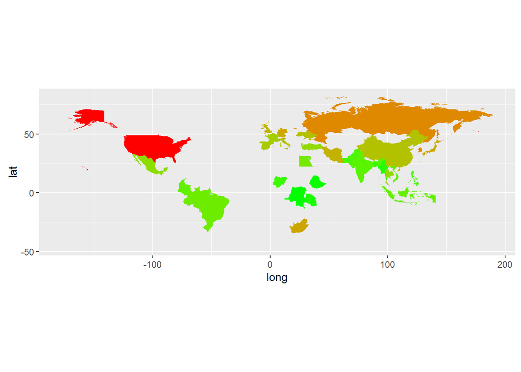

```r
map.world <- map_data(map="world")
a<- left_join(final[c(16, 18, 5)][final$Year==2010,], map.world[c(5, 2, 1, 3, 4)], by = c("Table.Name"="region"))

ggplot()+
  theme(legend.position="none")+
  geom_map(data=a, map=map.world, aes(map_id=`Table.Name`, x=long, y=lat, fill=`EN.ATM.CO2E.PC`))+
  scale_fill_gradient(low = "green", high = "red", guide = "colourbar")+
  coord_equal()
```

### 3.1.2 Total Emissions

Looking at total CO2 emission levels (metric tons), we can see that USA and China jump out.

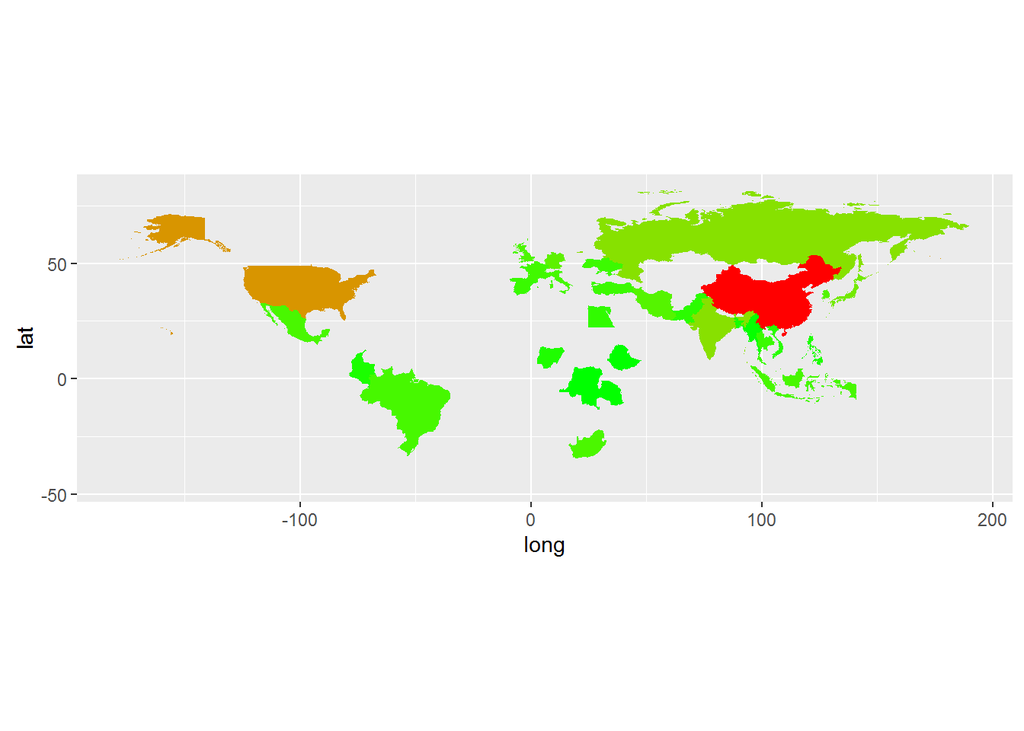

```r
map.world <- map_data(map="world")
a<- left_join(final[c(16, 18, 19)][final$Year==2010,], map.world[c(5, 2, 1, 3, 4)], by = c("Table.Name"="region"))

ggplot()+
  theme(legend.position="none")+
  geom_map(data=a, map=map.world, aes(map_id=`Table.Name`, x=long, y=lat, fill=`EN.ATM.CO2E`))+
  scale_fill_gradient(low = "green", high = "red", guide = "colourbar")+
  coord_equal()
```

### 3.1.3 Over the years

Now let us look at five countries specifically and try to understand the recent trend in their emissions and economies- China, USA, India, Russia and Japan

**Emissions:**

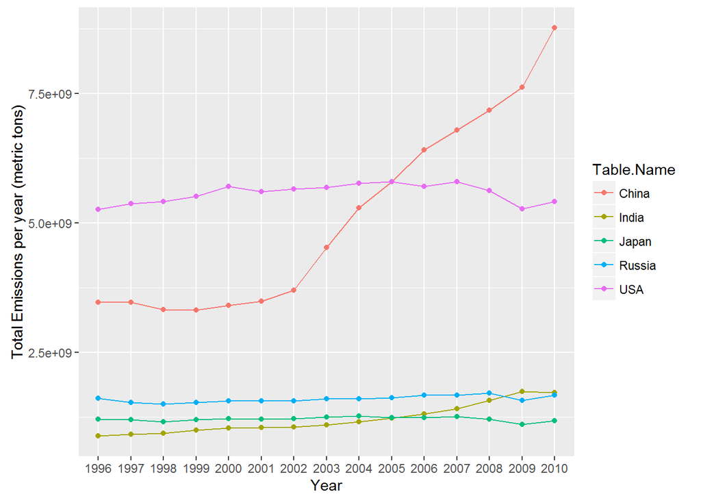

```r
final %>%
  filter(Country_Code %in% c("CHN","USA","RUS","IND","JPN")) %>%
  select(Table.Name, Year, EN.ATM.CO2E) %>%
  ggplot(aes(x=Year, y=EN.ATM.CO2E, group=Table.Name, colour=Table.Name)) +
    geom_line() +
    geom_point() +
    labs(y="Total Emissions per year (metric tons)")
```

**Energy Use:** Clearly, we can find a direct correlation between Energy Use and CO2 Emissions. For example, USA’s steady high use of energy can be refleted in their CO2 emissions. China’s high growth over the years in both the metrics is also pretty related.

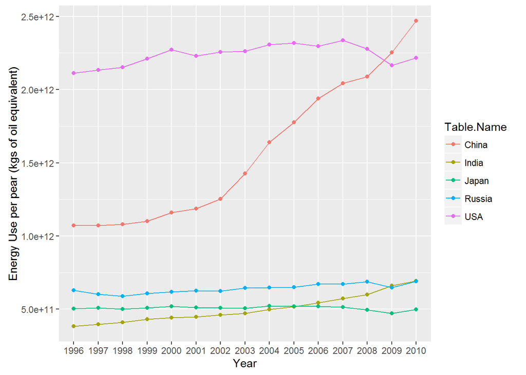

```r
final %>%
  filter(Country_Code %in% c("CHN","USA","RUS","IND","JPN")) %>%
  select(Table.Name, Year, EG.USE.KG.OE) %>%
  ggplot(aes(x=Year, y=EG.USE.KG.OE, group=Table.Name, colour=Table.Name)) +
    geom_line() +
    geom_point() +
    labs(y="Energy Use per pear (kgs of oil equivalent)")
```

### 3.1.4 Renewable Energy Sources

Let’s try to look at USA and China’s renewable energy usage and if these countries have had growth in renewable energy production. We can clearly see that a lack of funding in renewable energies could be a major reason for the CO2 emissions.

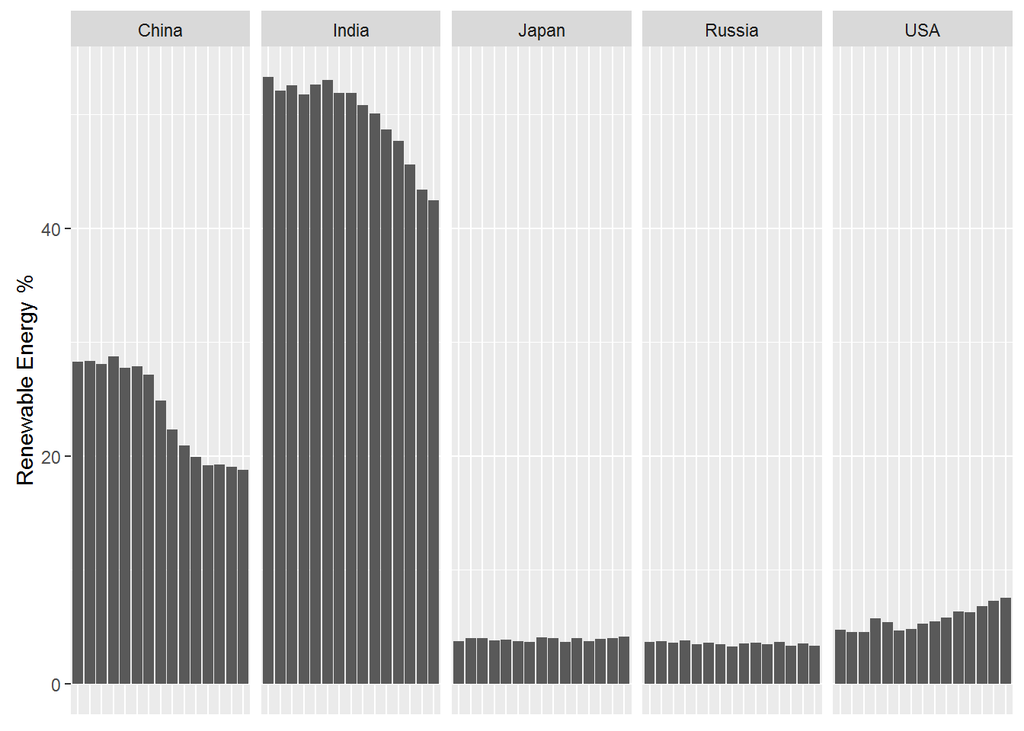

```r
final %>%
  filter(Country_Code %in% c("CHN","USA","RUS","IND","JPN")) %>%
  select(Table.Name, Year, `2.1_SHARE.TOTAL.RE.IN.TFEC` ) %>%
  ggplot(aes(x=Year, y=`2.1_SHARE.TOTAL.RE.IN.TFEC`)) +
  geom_bar(stat = "identity") +
  facet_wrap(~Table.Name, nrow=1) +
  theme(axis.title.x=element_blank(),
        axis.text.x=element_blank(),
        axis.ticks.x=element_blank())+
  labs(y= "Renewable Energy %")
```

## 3.2 Correlational Analysis

```r
a <- as.data.frame(rcorr(as.matrix(final[c(5, 3, 4, 6:15, 19)]))[[1]])[c(1,14)]
b <- as.data.frame(rcorr(as.matrix(final[c(5, 3, 4, 6:15, 19)]))[[3]])[c(1,14)]
correlations <- cbind(a,b)[c(1,3,2,4)]
correlations[] <- round(correlations, 2)
names(correlations) <- c("with Per Capita Emissions", "p-value", "with Total Emissions", "p-value")
datatable(correlations)
```

|  | with Per Capita Emissions | p-value | with Total Emissions | p-value |
| --- | --- | --- | --- | --- |
| EN.ATM.CO2E.PC | 1 |  | 0.57 | 0 |
| EG.ELC.ACCS.ZS | 0.55 | 0 | 0.26 | 0.04 |
| EG.USE.PCAP.KG.OE | 0.97 | 0 | 0.52 | 0 |
| EN.ATM.METH.KT.CE | 0.15 | 0 | 0.81 | 0 |
| SE.ADT.LITR.ZS | 0.5 | 0 | 0.17 | 0.11 |
| SI.POV.GINI | -0.24 | 0 | -0.04 | 0.66 |
| SI.POV.NAHC | -0.12 | 0.25 | -0.27 | 0.01 |
| SL.UEM.TOTL.ZS | 0.19 | 0 | -0.14 | 0 |
| SP.DYN.LE00.IN | 0.53 | 0 | 0.27 | 0 |
| SP.POP.TOTL | -0.06 | 0.24 | 0.62 | 0 |

[output cut: 4 more lines]

**Total Emissions**  
1. Methane and CO2 emissions are highly related to each other.  
2. Total population is related to total emissions, obviously.  
3. Demographics aren’t necessarily tied to CO2 emissions directly.

# 4 Summary

In this project, we analyzed the patterns around Carbon Emissions and how they are related to countries’ demographics, economic indicators and sustainable energy use. We also looked at the trends of countries with the highest Carbon and Methane Emissions. We can see that using our Data from Worldbank for these metrics helped us gain helpful insights into the major factors at play regarding global warming.